# Star and planet formation - Problem set 3

Simon Karlsson

E-mail: skrotupplag@hotmail.com

Date: 240518

```python
from __future__ import division
from astropy import constants as con
import scipy as sp
from scipy import integrate
import matplotlib.pyplot as plt
import numpy as np
from astropy import units as u
from IPython.display import Image
%matplotlib inline
```

## 1. The Minimum Solar Mass Nebula (MSMN)

**Q:**

The mass of the disk that formed the solar system planets is unknown. However, it is possible to estimate a lower limit to the mass the disk must have had by using the observed masses of the planets and scale them up to roughly solar abundance (i.e. “add” an appropriate mass of hydrogen & helium). Estimate the radial distribution of the MSMN by using the following procedure:

(a) Starting from the inferred masses of heavy elements (such as iron) in the planets, add enough mass of H and He to bring the composition up to solar abundance values.

(b) Spread the masses in annuli centered on the current semi-major axes of the planets and extending half-way to the neighbouring planets, and compute the surface density $\Sigma$ (mass per area, in the unit kg m$^{−2}$ ).

(c) Plot the resulting $\Sigma$ as a function of distance in a log-log diagram, and find the best fit for a function $\Sigma(r) = kr^{−\alpha}$ (where $k$ and $\alpha$ are fitted constants and $r$ is the radius) by fitting a straight line to the plotted values.

**A:**

a)

I start to solve this by looking up some numbers on wikipedia http://en.wikipedia.org/wiki/Solar_System#Mercury. I hope the article is accurate enough to look up elementary stuff as planet masses and distances. I insert my findings in the code cell below:

```python
AU = con.au
massEarth = con.M_earth
distEarth = AU

massMercury = 0.055*massEarth
distMercury =0.4*AU

massVenus = 0.815*massEarth
distVenus = 0.7*AU

massMars = 0.107*massEarth
distMars = 1.5*AU

massJupiter = 318*massEarth
distJupiter = 5.2*AU

massSaturn = 95*massEarth
distSaturn = 9.5*AU

massUranus = 14*massEarth
distUranus = 19.2*AU

massNeptune = 17*massEarth
distNeptune = 30*AU

planetRadius = np.array([distMercury.value,distVenus.value, distEarth.value, distMars.value, distJupiter.value,
                         distSaturn.value, distUranus.value, distNeptune.value])
```

```python
scaleMassMercury = massMercury / 0.014
scaleMassVenus = massVenus / 0.014
scaleMassEarth = massEarth / 0.014
scaleMassMars = massMars / 0.014
```

b) and c)

Next I want to smear all the individual masses over their respective surface area. At the time of writing I could not figure out a good algorithm to calculate the areas so I just brute forced myself through this (Tough guy warning!) by calculating all the radii as can be seen in the image below:.

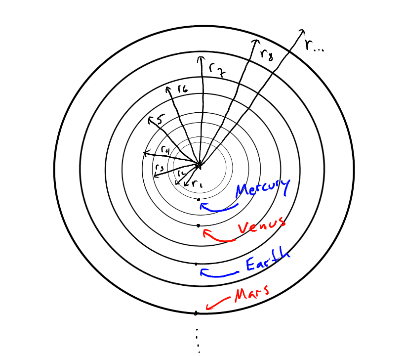

```python
Image('radiusArea.png')
```

```python
r1 = distMercury/2
r2 = distMercury
r3 = r2 + (distVenus-distMercury)/2
r4 = r3 + (distEarth-distVenus)/2
r5 = r4 + (distEarth-distVenus)/2
r6 = r5 + (distEarth-distVenus)/2
r7 = r6 + (distMars-distEarth)/2
r8 = r7 + (distMars-distEarth)/2
r9 = r8 + (distJupiter-distMars)/2
r10 = r9 + (distJupiter-distMars)/2
r11 = r10 + (distSaturn-distJupiter)/2
r12 = r11 + (distSaturn-distJupiter)/2
r13 = r12 + (distUranus-distSaturn)/2
r14 = r13 + (distUranus-distSaturn)/2
r15 = r14 + (distNeptune-distUranus)/2
r16 = r15 + (distNeptune-distUranus)/2
r17 = r16 + (distNeptune-distUranus)/2
```

```python
print r1/AU,r2/AU,r3/AU,r4/AU,r5/AU,r6/AU,r7/AU,r8/AU,r9/AU,r10/AU,r11/AU, r12/AU, r13/AU, r14/AU,r15/AU,r16/AU,r17/AU
```

```
0.2  0.4  0.55  0.7  0.85  1.0  1.25  1.5  3.35  5.2  7.35  9.5  14.35  19.2  24.6  30.0  35.4
```

As can be seen from the image I calculate a value for each radius all the way out to Neptune. I then use this to calculate the area in each ring as:

```python
A1 = np.pi*(r3**2-r1**2)
A2 = np.pi*(r5**2-r3**2)
A3 = np.pi*(r7**2-r5**2)
A4 = np.pi*(r9**2-r7**2)
A5 = np.pi*(r11**2-r9**2)
A6 = np.pi*(r13**2-r11**2)
A7 = np.pi*(r15**2-r13**2)
A8 = np.pi*(r17**2-r15**2)
```

```python
print A1,A2,A3,A4,A5,A6,A7,A8
```

```
1.84556780074e+22 m2 2.95290848118e+22 m2 5.90581696236e+22 m2 6.79168950671e+23 m2 3.00915435701e+24 m2 1.06796856736e+25 m2 2.80693285656e+25 m2 4.55591594239e+25 m2
```

Now I calculate the surface density by just dividing the planet mass (scaled in some cases) by the area:

```python
surfDensityMercury = scaleMassMercury / A1
surfDensityVenus = scaleMassVenus / A2
surfDensityEarth = scaleMassEarth / A3
surfDensityMars = scaleMassMars / A4
surfDensityJupiter = massJupiter / A5
surfDensitySaturn = massSaturn / A6
surfDensityUranus = massUranus / A7
surfDensityNeptune = massNeptune / A8
```

```python
surfDensity = np.array([surfDensityMercury.value, surfDensityVenus.value, surfDensityEarth.value, surfDensityMars.value,
                        surfDensityJupiter.value, surfDensitySaturn.value, surfDensityUranus.value, surfDensityNeptune.value])
```

```python
print surfDensity
```

```
[  1.27169923e+03   1.17776690e+04   7.22556378e+03   6.72291587e+01
   6.31338700e+02   5.31428562e+01   2.97972215e+00   2.22922023e+00]
```

I now take the log of these surface densities, log of the radii of the planets and then plot them in a log-log diagram:

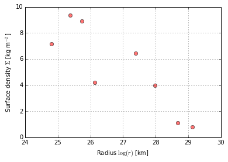

```python
x = np.log(planetRadius)
y = np.log(surfDensity)
plt.plot(x, y, linewidth=2, color='#FF7373',marker='o', linestyle='None')
plt.xlabel('Radius $\log (r)$ [km]')
plt.ylabel('Surface density $\Sigma$ [kg m$^{-2}$]')
plt.grid()
```

Now I make a polynomial fit to the data to find $\alpha$ and $k$:

```python
constants = np.polyfit(x,y,1)
alpha = constants[0]
logk= constants[1]
```

```python
print alpha,logk
```

```
-1.75102572559 52.3522062433
```

This means that $\alpha = 1.751$ and $k = e^{52.352}$

First I plot the relation in the log-log diagram to see if it is a reasonable fit:

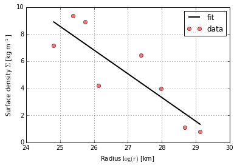

```python
y2 = constants[1] + constants[0] *x
plt.plot(x, y2, linewidth = 2, color='black', label='fit')
plt.plot(x, y, linewidth=2, color='#FF7373',marker='o', linestyle='None', label='data')
plt.xlabel('Radius $\log (r)$ [km]')
plt.ylabel('Surface density $\Sigma$ [kg m$^{-2}$]')
plt.legend()
plt.grid()
```

This looks good and now I use the derived constants to create the radial distribution function

$$ \Sigma(r) = e^{52.352} \cdot r^{-1.751}. $$

To plot this I just make a list of radial values and run them through the function and then plot the results:

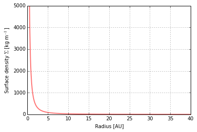

```python
x3 = np.linspace(0.5*AU.value,40*AU.value, 1000)
y3=  np.e**constants[1]*x3 **constants[0]
plt.plot(x3/AU.value, y3, linewidth=2, color='#FF7373')
plt.xlabel('Radius [AU]')
plt.ylabel('Surface density $\Sigma$ [kg m$^{-2}$]')
plt.grid()
```

```python
sigmaR = lambda r: (np.e**constants[1]*r**constants[0])*2*np.pi*r
totalMass = integrate.quad(sigmaR, 0.2*AU.value, 40*AU.value)
```

```python
totalMass[0]*u.kilogram
```

$1.52872\times 10^{+27} \; \mathrm{kg}$

In terms of solar mass this is

```python
totalMass[0]*u.kilogram/con.M_sun
```

$0.00076855 \; \mathrm{}$

A lower limit of the mass of the solar disk according to this argument is then roughly $0.0008M_{\odot}$.

## 2. Dust-gas dynamics

**Q:**

The orbital velocity of gas in an axisymmetric circum- stellar disk is not only dependent on the gravity from the central star, but also on the gas pressure gradient. The midplane radial equation of motion for gas in cylindrical coordinates is thus

$$ \ddot{r}-r \dot{\varphi}^2 = -\frac{GM_{\star}}{r^2} - \frac{1}{\rho}\frac{\partial P}{\partial r} $$

where $r$ and $\varphi$ are the cylindrical radius and azimuthal angle respectively, $G = 6.67 \cdot 10^{−11}$ m$^3$ kg$^{−1}$ s$^{−2}$ is the gravitational constant, $M$ is the stellar mass, $P$ is the gas pressure, and $ρ$ is the gas mass density. Assume that the gas is isothermal in circular orbit around the star, and that the radial midplane density is $\rho(r) = \rho_0(r/r_0 )^{−\alpha}$ .

(a) What is the orbital speed $v_{gas}(r) = r\dot{\varphi}(r)$ of the gas as a function of radius $r$? Use the isothermal equation of state.

(b) A dust grain of size s is orbiting at Keplerian speed $v_{dust}(r)$ at radius $r$, and so will experience a relative velocity with respect to the gas, giving rise to “Epstein drag"

$$ F_{drag} = -\frac{4}{3}\pi s^2 \rho v_{rel} v_{th} $$

where $v_{rel} = v_{dust} - v_{gas}$ is the relative velocity between the dust and the gas, and

$$ v_{th} = \sqrt{ \frac{8 k_B T}{\pi \mu m_H} } $$

is the thermal speed of the gas molecules, where $\mu$ is the mean molecular weight, $k_B = 1.38 \cdot 10^{−23}$ J K$^{−1}$ is the Boltzmann constant, and $m_H = 1.66 \cdot 10^{−27}$ kg is the hydrogen atom mass. Let the stopping time be defined by

$$ t_{stop} = \frac{m v_{rel}}{F_{drag}} $$

where $m = 4\pi s^3 \rho_{dust} /3$ is the mass for a spherical dust grain of size s and density \rho*{dust}. What is the stopping time as a function of the radius $r$ and dust grain size $s$? What is the dimensionless stopping time $T*{stop} = \dot{\varphi} t_{stop} ?

(c) Compute the dimensionless stopping time $T_{stop}$ for the specific case $s = 2 \mu m, r = 1$ AU, $T = 100$ K, $M_{\star} = 1 M_{\odot}$ , $r_0 = 1$ AU, $\alpha = 7/2$, $\rho_0 = 2 \cdot 10^{−12}$ kg cm$^{−3}$ , $\rho_{dust} = 3 \cdot 10^3$ kg cm$^{−3}$, and $\mu = 2$.

**A:**

a)

Assuming an equation of state as

$$ P = \rho c_S^2 $$

where

$$ \rho = \rho_0 r^{-\alpha} r_0^{\alpha} $$

and

$$ c_S = \sqrt{\frac{RT}{\mu}} $$

I derive the relation for the gas speed by hand below:

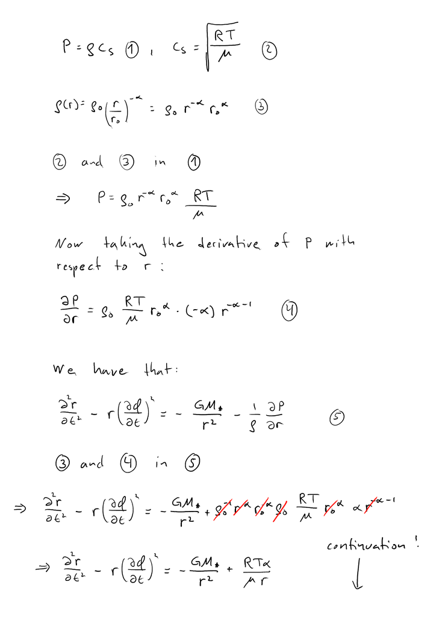

```python
Image('set3-21.png')
```

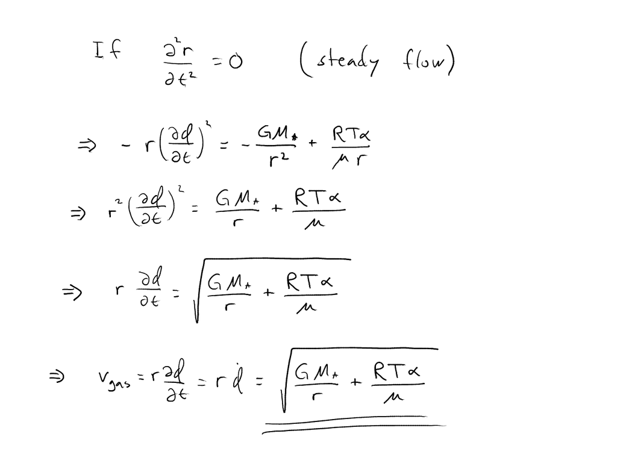

```python
Image('set3-22.png')
```

b)

I also derive the stopping time $t_{stop}$ and the dimensionless stopping time $T_{stop}$ by hand:

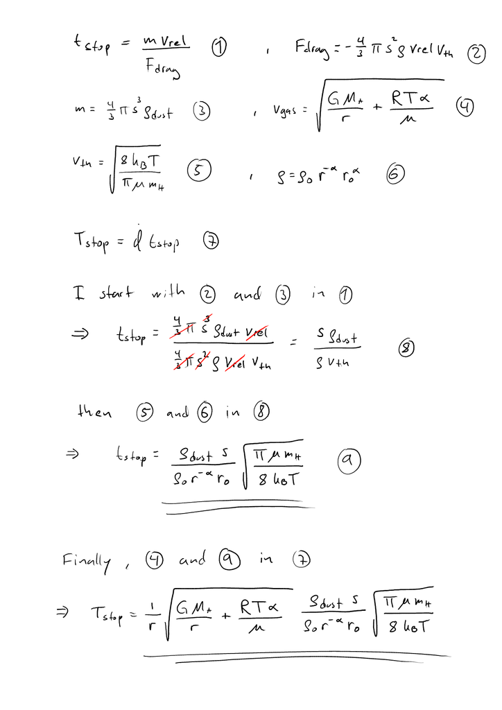

```python
Image('set3-23.png')
```

c)

In this final step I create a program that calculates $v_{gas}$, $t_{stop}$ and $T_{stop}$:

```python
#initialising values
G = con.G
R = con.R
pi = np.pi
mu = 2 * u.kilogram * u.mol**-1
mH = con.m_p
k = con.k_B
rhoDust = 3*10**3 *u.kilogram *u.meter**-3
rho0 = (2*10**-12 * u.kilogram * u.centimeter**-3).si
r0 = con.au
alpha = 7./2
r = con.au
T = 100 *u.Kelvin
Mstar = con.M_sun
s = 2*10**-6 *u.meter

#calculates gas speed
vGas = np.sqrt( ((G*Mstar)/r) - ((R*T*alpha) / mu))

#clculates stopping time
tStop = ( (rhoDust * s) / (rho0 * r**-alpha * r0**alpha) ) *np.sqrt( (pi * mu.value * mH) / (8*k * T) )

#calculates dimensionless stopping time
TStop = (1/r)* vGas * ( (rhoDust * s) / (rho0 * r**-alpha * r0**alpha) ) *np.sqrt( (pi * mu.value * mH) / (8*k * T) )
```

```python
vGas
```

$29788.8 \; \mathrm{\frac{m}{s}}$

The speed of the gas is then $v_{gas} = 29788.8$ m s$^{-1}$

```python
tStop.decompose()
```

$2.92633 \; \mathrm{s}$

The stopping time is $t_{stop} = 2.926$ s

```python
TStop.decompose()
```

$5.82708\times 10^{-07} \; \mathrm{}$

## 3. Gravitational instability

A criterion commonly used for determining disk stability against gravity is the Toomre criterion that states that a disk annulus can start to fragment when

$$ Q \equiv \frac{c_S \Omega}{\pi G \Sigma} < 1 $$

where $c_S$ is the sound speed, $\Omega$ is the orbital frequency, $G$ is the gravitational constant, and $\Sigma$ is the surface mass density.

(a) Using reasonable assumptions, compute $Q$ as a function of radius for the MSMN.

(b) Compute the critical surface density as a function of radius (i.e. for $Q = 1$) and compare it to the MSMN.

(c) A ‘clump’ in a disk will resist shear if it is Roche unstable, that is, if

$$ \rho > \rho_{Roche} \sim \frac{3.5 M_{\star}}{r^3} $$

where $\rho$ is the volume mass density, $r$ is the radius and $M_{\star}$ is the mass of the central star. Using some reasonable assumptions (e.g. for the scale height), compute the Roche critical surface density $\rho$ Roche and compare it to the MSMN and Toomre critical densities above.

a)

I assume isothermal equation of state with sound speed as

$$ c_S = \sqrt{\frac{R T}{\mu}}. $$

I also assume that the angular frequency can be expressed in terms of the gas speed in problem 2

$$ \Omega = \frac{v}{r} = \frac{1}{r} \sqrt{ \frac{G M_{\star} }{r} -\frac{R T \alpha}{\mu} } $$

and I assume that the surface density can be described as the one derived in problem 1

Finally I assume that $T = 100$ K, $\alpha = 7/2$, $\mu = 2$ and $M_{\star} = M_{\odot}$. With this I calculate $Q$ as a function of $r$ below:

```python
#initialising values
G = con.G
pi = np.pi
R = con.R
T = 100 *u.Kelvin
Mstar = con.M_sun
alpha = 7./2
cs = np.sqrt((R*T)/mu)
mu = 2 * u.kilogram * u.mol**-1
```

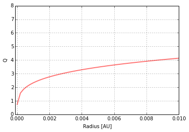

```python
r = np.linspace(0.00001*AU.value,2*AU.value, 10000) * u.meter
vGas = np.sqrt( ((G*Mstar)/r) - ((R*T*alpha) / mu))
sigma = np.e**constants[1] * r.value**constants[0]
Q = ( (cs*(vGas/r)) / (pi*G*sigma) )
plt.plot(r.value/con.au.value,Q.value ,linewidth=2, color='#FF7373')
plt.xlim(-0.0001,0.01)
plt.ylim(0,8)
plt.xlabel('Radius [AU]')
plt.ylabel('Q')
plt.grid()
```

From this plot we can see that with these assumptions the disk is only unstable very close to the sun, inside the radius of the sun. This means that the disk is not unstable at all.

b)

To derive the critical surface density as a function of $r$ I put the expression equal to one and solve for $\Sigma$

$$ Q = 1 = \frac{c_S \Omega}{\pi G \Sigma} \Leftrightarrow \Sigma = \frac{c_S \Omega}{\pi G}. $$

I plot this expression below:

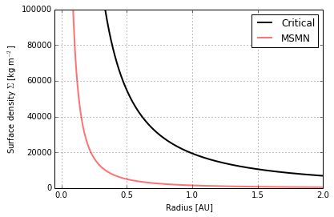

```python
r = np.linspace(0.05*AU.value,5*AU.value, 10000) * u.meter
vGas = np.sqrt( ((G*Mstar)/r) - ((R*T*alpha) / mu))
sigmaCrit = ((cs*(vGas/r)) / (pi*G))
plt.plot(r.value/con.au.value,sigmaCrit.value, linewidth=2, color='black', label='Critical')
plt.xlabel('Radius [AU]')
plt.ylabel('$\Sigma$_Critical [kg/m$^2$]')
plt.xlim(-0.05,2)
plt.ylim(0,100000)

y3=np.e**constants[1]*r**constants[0]
plt.plot(r.value/AU.value, y3.value, linewidth=2, color='#FF7373', label='MSMN')
plt.xlabel('Radius [AU]')
plt.ylabel('Surface density $\Sigma$ [kg m$^{-2}$]')
plt.grid()
plt.legend()
```

From this plot we see that the critical surface density is much higher than the predicted values from the MSMN-model.

c)

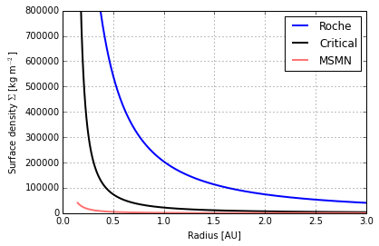

```python
r = np.linspace(0.15*AU.value,5*AU.value, 10000) * u.meter
h=cs/(vGas/r)
roche = (3.5*Mstar*h) / r**3
plt.figure(1)
plt.plot(r.value/AU.value,roche.value, linewidth=2, color='blue', label='Roche')
plt.xlabel('Radius [AU]')
plt.ylabel('$\\rho$_Roche [kg/m$^2$]')
plt.xlim(0.002,3)

plt.plot(r.value/con.au.value,sigmaCrit.value, linewidth=2, color='black', label='Critical')
plt.xlabel('Radius [AU]')
plt.ylabel('$\Sigma$_Critical [kg/m$^2$]')
plt.ylim(0,800000)

y3=np.e**constants[1]*r**constants[0]
plt.plot(r.value/AU.value, y3.value, linewidth=2, color='#FF7373', label='MSMN')
plt.xlabel('Radius [AU]')
plt.ylabel('Surface density $\Sigma$ [kg m$^{-2}$]')
plt.grid()
plt.legend()
```

Now we can see that the MSMN is much lower than both the critical density and the density at which the matter starts to resist shear in the disk.